# Polymorphic Wikipedia Graph Explorer

Data Structures, Objects & Algorithms Project

Author

Affiliation

Troy Cheng, Stacy Che

Georgetown University

Published

April 30, 2026

Modified

April 28, 2026

## 1 Abstract

Browsing Wikipedia, I have a habit: I open every interesting link in a new tab, then read them one by one before closing them. I can end up with 10, 15, even 20 tabs — all stemming from the original article I started with. I stay close to the source topic. I don’t get lost. While my teammate Troy does the exact opposite of click a link, read it, click another link inside *that* article, read it, and keep going. He never open a new tab. An hour later he would have completely forgotten what they originally searched for and are deep in some unrelated corner of the internet fascinated.

We then realized that these two browsing styles are literally **Breadth-First Search** and **Depth-First Search**.

- **Tab-hoarder (BFS):** Queue up all the links first, read them layer by layer. Stay close to the original topic.
- **Rabbit-hole diver (DFS):** Follow each link immediately before finishing the current one. Dive deep, drift far.

This project turns our observation into code. We built a **Wikipedia Graph Explorer** that treats articles as nodes and hyperlinks as edges. By swapping one object — a `Queue` for a `Stack` — the same explorer can either stay close to home like a tab-hoarder, or wander into unknown territory like a rabbit-hole diver. The core question: *Does that one swap actually change what you discover?* The answer turns out to be YES!

We built three features on top of this: - a BFS-vs-DFS exploration comparison - a shortest-path finder (the automated Wikipedia game) - a knowledge distance mindmap demoed on Georgetown University at its center

## 2 Research Question

**How can BFS, DFS, and object-oriented polymorphism be used to explore, compare, and map knowledge connections in Wikipedia as a graph?**

More concretely:

- Does changing Stack → Queue actually change *which* Wikipedia pages you discover?
- How many clicks does it take to get from any article to any other article?
- How “far” is Georgetown University from Ancient Rome, Dinosaurs, or Data science measured in hyperlink hops?

## 3 Course Foundations: BST Traversal

The foundation of this project comes directly from the Binary Search Tree (BST) traversal exercises in the DSAN 5500 homework 3. In the original assignment, we built a `BinarySearchTree` composed of linked `BSTNode` objects and used a `ThingContainer` abstraction to control traversal order. By choosing either a `Stack` or a `Queue`, the same traversal engine could behave like Depth-First Search (DFS) or Breadth-First Search (BFS).

This was the first important idea that shaped our final project. We realized that traversal algorithms are not limited to trees. They are general strategies for exploring structured systems. What changes is not the algorithm itself, but the definition of what counts as a node and what counts as a child.

In the BST homework, each node has at most two children: a left child and a right child. In the Wikipedia explorer, each Wikipedia page becomes a node, and the hyperlinks on that page become its children. Instead of traversing a binary tree, we are now traversing a graph of connected knowledge.

The key observation is that the loop inside `NodeProcessor.iterate_over()` from the homework is structurally identical to the loop inside `WikiExplorer.explore()` in this project. The algorithm remains the same. Only the meaning of the node and its neighbors changes.

| Course Homework (BST) | Final Project (Wikipedia Graph) |
| --- | --- |
| BSTNode | WikiNode |
| node.left, node.right | hyperlinks on a Wikipedia page |
| ThingContainer | Frontier |
| Stack | DFSFrontier |
| Queue | BFSFrontier |
| NodeProcessor | WikiExplorer |

This structural equivalence is the reason this project belongs naturally in DSAN 5500. We are not replacing course concepts with a new project. Instead, we are extending the exact same traversal logic from a controlled classroom example into a real-world information network.

```python
import sys
sys.path.insert(0, ".")

from src.bst import (
    WikiPage,
    BinarySearchTree,
    Stack,
    Queue,
    IterAlgorithm,
    NodeProcessor,
)
```

```python
pages = [
    "Machine learning",
    "Data science",
    "Statistics",
    "Artificial intelligence",
    "Python (programming language)",
    "Deep learning",
    "Neural network",
]

bst = BinarySearchTree()

for title in pages:
    bst.add(WikiPage(title))

print(f"Tree has {len(bst)} nodes")
print("repr:", repr(bst))
print("str:", str(bst))
```

```
Tree has 7 nodes
repr: BinarySearchTree[Machine learning]
str: BinarySearchTree[Data science,Machine learning,Statistics]
```

The example above builds a BST using Wikipedia page titles instead of ordinary inventory items. This helps connect the homework structure directly to the final project. The tree still behaves like a standard BST, but the content now reflects the domain of our Wikipedia explorer.

```python
print("=== DFS (Stack / LIFO) ===")
dfs = NodeProcessor(IterAlgorithm.DEPTH_FIRST)
dfs.iterate_over(bst)

print("=== BFS (Queue / FIFO) ===")
bfs = NodeProcessor(IterAlgorithm.BREADTH_FIRST)
bfs.iterate_over(bst)
```

```
=== DFS (Stack / LIFO) ===
Machine learning
Statistics
Python (programming language)
Neural network
Data science
Deep learning
Artificial intelligence
=== BFS (Queue / FIFO) ===
Machine learning
Data science
Statistics
Artificial intelligence
Deep learning
Python (programming language)
Neural network
```

This demonstrates how simply changing the underlying container changes the traversal behavior. DFS uses a stack and explores deeply before backtracking, while BFS uses a queue and visits nodes layer by layer. This same principle becomes the core design of our Wikipedia explorer.

## 4 From BST to Wikipedia Graph Explorer

After establishing the connection to BST traversal, the next step is to redefine the structure being explored. In the homework, the structure was a binary search tree. Each node had a fixed relationship to its children because it could only have a left child, a right child, or both. In this project, the structure is Wikipedia, which is much larger and less predictable. Each page can link to many other pages, and those pages can also link back to earlier pages. This makes Wikipedia closer to a graph than a tree.

The important design shift is that we keep the traversal pattern but change the source of the children. In a BST, the children are already stored inside the node as `left` and `right`. In Wikipedia, the children are discovered dynamically by scraping the hyperlinks from each page. This means the explorer does not know all possible nodes in advance. It gradually builds the graph as it visits pages.

Conceptually, the process works like this:

```
Start with one Wikipedia page
Take the next page from the frontier
Fetch the links on that page
Treat those links as neighboring nodes
Add unvisited neighbors back into the frontier
Record the page and its connections in the graph
Repeat until the page or depth limit is reached
```

This is the same traversal logic used in the BST homework, but applied to a real information network. The difference is that Wikipedia introduces cycles and repeated links. For example, “Data science” may link to “Machine learning,” and “Machine learning” may link back to “Data science” or to another page that has already been discovered. Because of this, the project needs a visited set to avoid processing the same page repeatedly.

```python
from src import WikiScraper, WikiGraph, WikiNode

graph = WikiGraph()

graph.mark_visited("Cat")
graph.add_edge("Cat", "Felidae")
graph.add_edge("Cat", "Mammal")
graph.add_edge("Cat", "Carnivore")

print(graph)
print("Neighbors of Cat:")
for neighbor in graph.neighbors("Cat"):
    print("-", neighbor)
```

```
WikiGraph(nodes=1, edges=3)
Neighbors of Cat:
- Felidae
- Mammal
- Carnivore
```

This toy example builds the graph manually — no network calls needed. “Cat” is marked as visited, and three edges represent hyperlinks found on the Cat Wikipedia page. Internally, `WikiGraph` stores these as an adjacency list, so the explorer can quickly look up which pages can be reached from “Cat.”

In the real project, `WikiScraper` generates these neighbor lists automatically by downloading and parsing Wikipedia HTML:

```python
scraper = WikiScraper(delay=0.2)

links = scraper.get_links("Cat")[:10]

print("First 10 internal Wikipedia links found on the 'Cat' page:")
for link in links:
    print("-", link)
```

```
First 10 internal Wikipedia links found on the 'Cat' page:
- Felidae
- Cat (disambiguation)
- Cats (disambiguation)
- Megaannum
- Precambrian
- Cambrian
- Ordovician
- Silurian
- Devonian
- Carboniferous
```

This step is where the project moves from a toy data structure into a real-world network. The algorithm is still the same, but the data is no longer manually constructed. Instead, each page generates its own neighboring nodes through its hyperlinks.

The table below summarizes the shift from the course example to the final project:

| Design Element | BST Traversal | Wikipedia Graph Explorer |
| --- | --- | --- |
| Starting point | Root of the tree | Starting Wikipedia page |
| Node | BST node | Wikipedia article |
| Children or neighbors | Left and right child | Hyperlinks extracted from page |
| Traversal container | Stack or Queue | DFSFrontier or BFSFrontier |
| Repeated visits | Usually not an issue | Must be handled with a visited set |
| Output | Printed node contents | Explored graph and paths |

This transition is the conceptual center of the project. We are not simply using Wikipedia as a dataset. We are using Wikipedia to show how a traversal algorithm can be generalized from a tree to a graph, and from a classroom example to a real exploratory tool.

## 5 Core OOP Design: Frontier Polymorphism

One of the most important design decisions in this project is the use of object-oriented polymorphism. Instead of writing separate programs for Breadth-First Search (BFS) and Depth-First Search (DFS), we designed a single exploration system that can switch traversal behavior by changing only one object. This allows the same `WikiExplorer` class to behave differently without rewriting its internal logic.

In the original BST homework, traversal order was controlled by a `ThingContainer`. If the container was a `Stack`, the traversal behaved like Depth-First Search because the most recently added node was explored first. If the container was a `Queue`, the traversal behaved like Breadth-First Search because the earliest discovered node was explored first. The algorithm itself did not change. Only the behavior of the container changed.

This same idea becomes the center of the Wikipedia explorer. Instead of directly using `Stack` and `Queue`, we define an abstract class called `Frontier`. The `Frontier` class provides a general interface with three basic operations:

- `add()` → place a new page into the frontier
- `pop()` → remove the next page to explore
- `is_empty()` → check whether exploration should stop

The `WikiExplorer` only depends on this interface. It does not need to know whether the frontier is implemented using a queue, a stack, or something else. This separation is what makes the design flexible.

Two concrete subclasses inherit from `Frontier`:

1. `BFSFrontier`
2. `DFSFrontier`

`BFSFrontier` wraps the `Queue` class from the course homework. It uses first-in, first-out (FIFO) behavior, which means pages are explored layer by layer. This keeps the traversal close to the starting topic and is especially useful for shortest-path problems.

`DFSFrontier` wraps the `Stack` class from the homework. It uses last-in, first-out (LIFO) behavior, which means the most recently discovered page is explored next. This causes the system to dive deeply into one chain of pages before returning, which is useful for exploratory discovery.

The important point is that both classes expose the same methods. From the perspective of `WikiExplorer`, they are interchangeable.

```python
from src.frontier import BFSFrontier, DFSFrontier

bfs_frontier = BFSFrontier()
dfs_frontier = DFSFrontier()

print(f"BFSFrontier wraps: {type(bfs_frontier._container).__name__}")
print(f"DFSFrontier wraps: {type(dfs_frontier._container).__name__}")
```

```
BFSFrontier wraps: Queue
DFSFrontier wraps: Stack
```

The output confirms that BFSFrontier internally uses a Queue, while DFSFrontier uses a Stack. However, the explorer does not directly interact with these internal structures. It only calls the shared interface methods.

This is the practical meaning of polymorphism in this project. The same code:

```
frontier.add(page)
next_page = frontier.pop()
```

can behave as BFS or DFS depending on which frontier object is passed into the system.

This means we are not maintaining two different exploration programs. We are maintaining one general exploration engine with interchangeable traversal strategies. This is cleaner, easier to test, and easier to extend. For example, if we wanted to add a Priority Frontier in the future for heuristic search, we could do so without changing the internal logic of WikiExplorer.

The code below demonstrates that the same explorer can be initialized with different frontier objects while keeping the rest of the system unchanged.

```python
from src import WikiExplorer, WikiScraper

scraper = WikiScraper(delay=0.2)

bfs_explorer = WikiExplorer(
    frontier=BFSFrontier(),
    scraper=scraper,
    max_pages=10,
    max_depth=1,
    verbose=False
)

dfs_explorer = WikiExplorer(
    frontier=DFSFrontier(),
    scraper=scraper,
    max_pages=10,
    max_depth=1,
    verbose=False
)

print("BFS explorer uses:", type(bfs_explorer.frontier).__name__)
print("DFS explorer uses:", type(dfs_explorer.frontier).__name__)
```

```
BFS explorer uses: BFSFrontier
DFS explorer uses: DFSFrontier
```

Even though both explorers use the same class, they will produce different exploration patterns because the frontier object changes the order in which pages are processed.

This object-oriented structure is one of the strongest parts of the project because it connects directly to the course theme of data structures and object-oriented programming. The traversal strategy is no longer hardcoded into the algorithm. Instead, it becomes a replaceable component. This makes the system not only technically correct, but also well-designed from a software engineering perspective.

## 6 Modeling Wikipedia as a Graph

After establishing the traversal logic and the object-oriented structure, the next step is to define what exactly is being explored. In this project, Wikipedia is modeled as a directed graph. Each Wikipedia article is treated as a node, and each hyperlink from one article to another is treated as a directed edge.

For example, if the page “Data science” contains a hyperlink to “Machine learning,” the system records a directed connection from “Data science” to “Machine learning.” This creates a network of knowledge where concepts are connected through references and topic relationships.

This structure is fundamentally different from a binary search tree. In a BST, every node has a fixed maximum of two children, and the relationships are already known when the tree is built. In Wikipedia, a page may contain dozens or even hundreds of links, and these neighboring pages are only discovered when the page is visited. This makes the structure dynamic and much more complex.

Another major difference is the existence of cycles. In a BST, traversal usually does not risk infinite loops because the structure is acyclic. In Wikipedia, cycles happen naturally. For example, “Data science” may link to “Machine learning,” and “Machine learning” may link back to “Data science.” Without additional control, the explorer could revisit the same pages forever.

To solve this problem, the project uses a `visited` set. Every time a page is processed, its title is added to the set. Before exploring a new page, the system first checks whether it has already been visited. This prevents repeated work and guarantees that traversal eventually stops.

This design also connects back to a concept from the BST homework. In the BST, searching for an item could be done in approximately O(log n) time when the tree is balanced. In the Wikipedia explorer, we use a Python `set` for visited tracking, which provides average O(1) lookup through hashing. This makes repeated membership checks much more efficient for large graphs.

The graph itself is stored using an adjacency list. This means that for each page, the system stores a list of neighboring pages that can be reached directly from it. This structure is efficient for traversal because the explorer only needs to retrieve the neighbors of the current page instead of storing a large adjacency matrix for the entire network.

The `WikiGraph` class maintains three main components: the `adjacency` dictionary records directed edges between pages, the `visited` set stores pages that have already been explored, and the `parents` dictionary records how each page was reached during traversal. The `parents` dictionary is especially important for shortest-path reconstruction. When the explorer reaches a target page, it can trace backwards through the parent chain to rebuild the full path from the starting page.

```python
from src import WikiGraph

graph = WikiGraph()

graph.mark_visited("Cat")
graph.add_edge("Cat", "Felidae")
graph.add_edge("Cat", "Mammal")
graph.add_edge("Cat", "Carnivore")

print(graph)
print("Neighbors of Cat:")

for neighbor in graph.neighbors("Cat"):
    print("-", neighbor)
```

```
WikiGraph(nodes=1, edges=3)
Neighbors of Cat:
- Felidae
- Mammal
- Carnivore
```

We manually built a tiny 3-node graph centered on “Cat.” In the full project, these edges come from live Wikipedia scraping — the explorer builds this graph automatically as it visits pages.

```python
from src import WikiScraper

scraper = WikiScraper(delay=0.2)

links = scraper.get_links("Cat")[:10]

print("First 10 internal Wikipedia links found on the 'Cat' page:")

for link in links:
    print("-", link)
```

```
First 10 internal Wikipedia links found on the 'Cat' page:
- Felidae
- Cat (disambiguation)
- Cats (disambiguation)
- Megaannum
- Precambrian
- Cambrian
- Ordovician
- Silurian
- Devonian
- Carboniferous
```

This is the point where the project moves from a classroom data structure into a real-world exploration system. The traversal algorithm itself remains the same, but the source of the graph is no longer manually constructed. Each page generates its own neighbors, allowing the explorer to gradually build a real knowledge network.

The table below summarizes this transition:

| Design Element | BST Traversal | Wikipedia Graph Explorer |
| --- | --- | --- |
| Starting point | Root of the tree | Starting Wikipedia page |
| Node | BST node | Wikipedia article |
| Children | Left and right child | Hyperlinks extracted from page |
| Traversal structure | Tree | Directed graph |
| Traversal container | Stack or Queue | DFSFrontier or BFSFrontier |
| Repeated visits | Usually not an issue | Must be controlled with a visited set |
| Output | Printed node contents | Explored graph and reconstructed paths |

This modeling step is the conceptual center of the project. We are not simply using Wikipedia as a dataset. We are using it to show how traversal algorithms can be generalized from trees to graphs and from classroom exercises to practical systems for exploring connected knowledge.

## 7 Feature 1: BFS vs DFS Exploration

Remember the tab-hoarder vs. the rabbit-hole diver from the Abstract? This experiment is literally that — automated.

We run both BFS and DFS starting from the same Wikipedia page (`"Cat"`) with the same 20-page limit. The only difference is the frontier object we pass in: `BFSFrontier()` (wrapping a Queue) vs. `DFSFrontier()` (wrapping a Stack). Every other line of code is identical.

**BFS — the tab-hoarder:** Queues up all links from “Cat” before moving on. Reads them layer by layer. Stays close to the original topic.

**DFS — the rabbit-hole diver:** Follows the first link it finds immediately, then the first link from *that* page, and so on. Never comes back to the tab it didn’t open. Wanders fast, wanders far.

```python
from src import BFSFrontier, DFSFrontier, WikiScraper, WikiExplorer

START_PAGE = "Cat"
MAX_PAGES  = 20
MAX_DEPTH  = 2

scraper = WikiScraper(delay=0.2)

bfs_explorer = WikiExplorer(
    frontier=BFSFrontier(),
    scraper=scraper,
    max_pages=MAX_PAGES,
    max_depth=MAX_DEPTH,
    verbose=False
)
bfs_graph = bfs_explorer.explore(START_PAGE)

dfs_explorer = WikiExplorer(
    frontier=DFSFrontier(),
    scraper=scraper,
    max_pages=MAX_PAGES,
    max_depth=MAX_DEPTH,
    verbose=False
)
dfs_graph = dfs_explorer.explore(START_PAGE)
```

```python
bfs_only = bfs_graph.visited - dfs_graph.visited
dfs_only = dfs_graph.visited - bfs_graph.visited
shared   = bfs_graph.visited & dfs_graph.visited

print(f"Pages visited by BOTH:     {len(shared)}")
print(f"Pages visited by BFS only: {len(bfs_only)}")
print(f"Pages visited by DFS only: {len(dfs_only)}")
print()
print("BFS-only sample:", sorted(bfs_only)[:5])
print("DFS-only sample:", sorted(dfs_only)[:5])
```

```
Pages visited by BOTH:     1
Pages visited by BFS only: 19
Pages visited by DFS only: 19

BFS-only sample: ['Cambrian', 'Carboniferous', 'Cat (disambiguation)', 'Cats (disambiguation)', 'Conservation status']
DFS-only sample: ['Academic authorship', 'Bibcode (identifier)', 'Biological type', 'Doi (identifier)', 'Encyclopedia of Life']
```

When we actually ran this, BFS stayed in biology: Felidae, Mammal, Carnivora, Precambrian, Taxonomy. Every page made sense for “Cat.”

Starting from “Cat.” The two searches shared only 1 page (Cat itself). This is the whole point — **one line of code change** (`BFSFrontier()` → `DFSFrontier()`) produces a completely different knowledge map.

[figure not shown]

## 8 Feature 2: Shortest Path Between Wikipedia Pages

Ever played the Wikipedia game — clicking hyperlinks trying to get from one article to another in as few clicks as possible? This feature automates that game and reports the exact minimum path.

The key insight is why BFS (not DFS) is correct here. BFS expands outward layer by layer — first all pages 1 click away, then 2 clicks, then 3 clicks. So the *first* time it reaches the target, that path is guaranteed to be the shortest. DFS might find *a* path but not necessarily the *shortest* one.

In this first example, we search from `"Cat"` to `"Science"`:

```python
from src import BFSFrontier, WikiScraper, WikiExplorer

START  = "Cat"
TARGET = "Science"

# max_pages guide:
#   closely related (e.g. Data science → Deep learning) : 100-200
#   loosely related (e.g. Cat → Science)                : 300-500
#   very distant   (e.g. Cat → Ancient Rome)            : 500-1000 (slow, ~5 min)

explorer = WikiExplorer(
    frontier=BFSFrontier(),
    scraper=WikiScraper(delay=0.2),
    verbose=False,
)

path = explorer.shortest_path(START, TARGET, max_pages=400)

if path:
    print(f"Shortest path: {len(path) - 1} hops")
    for i, page in enumerate(path):
        arrow = "START  " if i == 0 else ("TARGET " if i == len(path)-1 else f"step {i}  ")
        print(f"  {arrow} → {page}")
else:
    print("No path found within the page limit.")
```

```
Shortest path: 2 hops
  START   → Cat
  step 1   → Megaannum
  TARGET  → Science
```

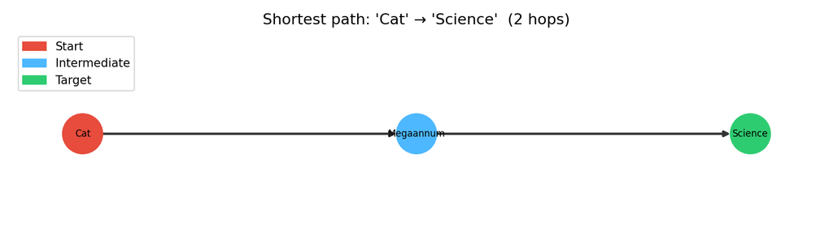

We can also search multiple pairs at once to compare distances across very different topics:

```python
from src import BFSFrontier, WikiScraper, WikiExplorer

PAIRS = [
    # (start, target, max_pages)
    # Close topics — fast (< 30 s)
    ("Data science",   "Deep learning",  200),
    ("Data science",   "Statistics",     200),
    # Medium/far — how far can Cat reach?
    ("Cat",            "Ancient Rome",   500),
    ("Cat",            "Dinosaur",       500),
]

scraper = WikiScraper(delay=0.2)

for start, target, limit in PAIRS:
    exp = WikiExplorer(frontier=BFSFrontier(), scraper=scraper, verbose=False)
    p   = exp.shortest_path(start, target, max_pages=limit)
    if p:
        print(f"{start!r:30s} → {target!r}: {len(p)-1} hops")
        print("  Path:", " → ".join(p))
    else:
        print(f"{start!r} → {target!r}: NOT FOUND within {limit} pages")
    print()
```

```
'Data science'                 → 'Deep learning': 2 hops
  Path: Data science → Machine learning → Deep learning

'Data science'                 → 'Statistics': 1 hops
  Path: Data science → Statistics

'Cat'                          → 'Ancient Rome': 2 hops
  Path: Cat → Megaannum → Ancient Rome

'Cat'                          → 'Dinosaur': 2 hops
  Path: Cat → Precambrian → Dinosaur
```

The `parents` dictionary is what makes path reconstruction possible. During BFS, every time we discover a new page, we record which page we came from. Once BFS lands on the target, we trace those parent pointers backward to rebuild the full path:

[output not shown]

## 9 Feature 3: Knowledge Mindmap

The mindmap is probably the most interesting output of the whole project, because it lets you ask: **“How far is Georgetown University from everything else?”**

```python
from src import WikiMindmap, WikiScraper

CENTER = "Georgetown University"

TARGETS = [
    "Bulldog",                               # Georgetown's mascot — expected close
    "John Carroll (archbishop of Baltimore)", # Georgetown's founder — expected close
    "Washington, D.C.",                      # Georgetown's home city — expected close
    "Data science",                          # Georgetown's DSAN program — expected moderate
    "Ancient Rome",                          # Jesuit connection — expected moderate
    "Dinosaur",                              # unrelated — expected far
]

scraper = WikiScraper(delay=0.1)

mindmap = WikiMindmap(
    center=CENTER,
    scraper=scraper,
    max_pages=500,   # ~2-3 min total; distant targets need more budget
    verbose=False,
)

mindmap.build(TARGETS)
mindmap.summary()
```

```
============================================================
Knowledge distance from: 'Georgetown University'
============================================================
Target                                    Hops  Path
------------------------------------------------------------
John Carroll (archbishop of Baltimore)       1  Georgetown University → John Carroll (archbishop of Baltimore)
Washington, D.C.                             1  Georgetown University → Washington, D.C.
Bulldog                                      2  Georgetown University → Georgetown Hoyas → Bulldog
Data science                                 2  Georgetown University → Master of Science in Foreign Service → Data science
Ancient Rome                                 2  Georgetown University → Latin language → Ancient Rome
Dinosaur                                     –  (not found within 500 pages)
============================================================
```

```python
closest  = mindmap.closest()
farthest = mindmap.farthest()

if closest:
    print(f"Closest:  {closest.target}  ({closest.hops} hops)")
    print("  Path:", " → ".join(closest.path))

if farthest:
    print(f"\nFarthest: {farthest.target}  ({farthest.hops} hops)")
    print("  Path:", " → ".join(farthest.path))
```

```
Closest:  John Carroll (archbishop of Baltimore)  (1 hops)
  Path: Georgetown University → John Carroll (archbishop of Baltimore)

Farthest: Bulldog  (2 hops)
  Path: Georgetown University → Georgetown Hoyas → Bulldog
```

```
Saved to notebooks/mindmap.png
```

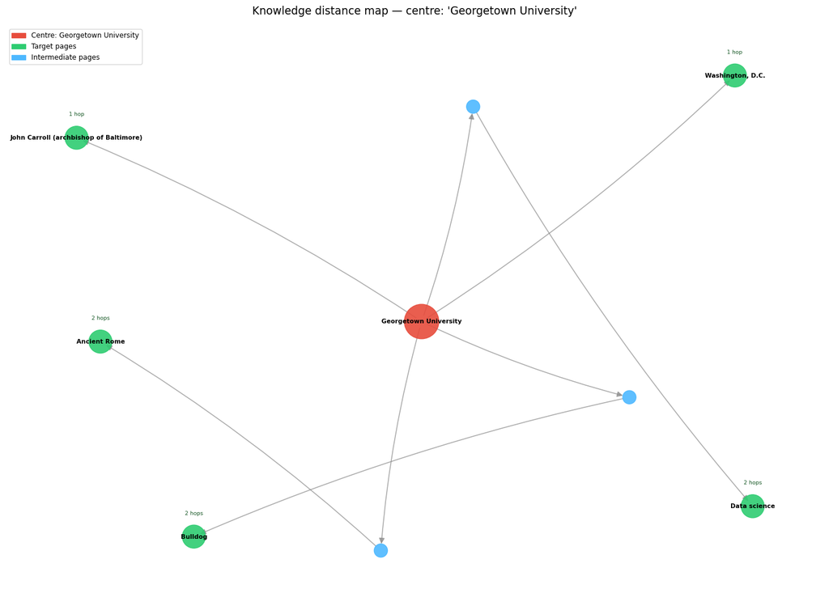

```python
mindmap.visualize(figsize=(15, 11), save_path="notebooks/mindmap.png")
```

[figure not shown]

Knowledge distance map centered on Georgetown University. Red = center, green = targets, blue = intermediate pages.

**How to read the visualization:**

- **Red node** — Georgetown University (the center)
- **Green nodes** — the target articles we searched for
- **Blue nodes** — intermediate Wikipedia pages that appeared on the shortest paths
- **Arrows** — direction of the hyperlink (A → B means A’s page links to B)

This turns BFS from a navigation tool into a *conceptual distance meter*. The output is no longer just “here’s a path” — it’s a window into how Wikipedia’s link structure connects Georgetown to the rest of human knowledge.

## 10 Discussion

Looking back at what we built, the thing that surprised us most was **how much the frontier choice actually matters in practice**. We expected BFS and DFS to explore the same graph in different orders. We didn’t expect them to end up in completely different neighborhoods after just 20 pages. Starting from “Cat,” BFS was still talking about Felidae and Carnivora. DFS was at *Douche and Turd* (a South Park episode). Same starting point. Same code. One line changed.

That’s the core insight of this project: **data structures are not neutral containers**. Choosing a Stack vs. a Queue isn’t just an implementation detail — it fundamentally changes what the system discovers first, and under page/depth limits, it changes what the system discovers *at all*.

**What didn’t work perfectly:**

- Wikipedia’s scale means we have to cap `max_pages`. Some paths don’t get found even if they exist — we just run out of budget. Increasing `max_pages` helps but makes the search slower.
- All hyperlinks are treated as equal. “Cat” linking to “Felidae” (its scientific family) and “Cat” linking to “Cats (musical)” are treated as the same-weight edge. In reality they’re very different semantically.
- The scraper depends on Wikipedia’s current HTML structure. If Wikipedia changes their page layout, `get_links()` might break silently.

**What could be improved:**

- Weighted edges based on link position or frequency (links in the first paragraph probably matter more)
- A* or greedy search if we had a semantic similarity score to use as a heuristic
- Caching scraped pages so re-running the same search is faster
- A live visualization that updates as BFS expands, to show the wavefront spreading outward

## 11 Conclusion

We started this project with a question from homework: *if you swap Stack for Queue in a traversal loop, what changes?* The answer, applied to Wikipedia, turns out to be: **everything**.

The same `WikiExplorer` class, with the same `explore()` method, produces totally different knowledge maps depending on whether you hand it a `BFSFrontier` or a `DFSFrontier`. This isn’t abstract polymorphism theory — we ran it and watched BFS stay close to “Cat” while DFS wandered into South Park in under 20 steps.

The bigger takeaway is that Wikipedia is a massive directed graph, and graph algorithms are the right tool for exploring it. The data structures we learned in class — stacks, queues, BSTs, adjacency lists, visited sets — all show up naturally once you frame the problem correctly. We didn’t need to invent anything new. We just had to recognize the structure.